December 2019

```r
library(here)
library(tidyverse)
library(lme4)
library(BayesFactor)
library(brms)
frames <- read_csv(here("data", "results_frames_ex2.csv"))
```

If you’d done the sampling frames experiment, which analyses would you actually report in a paper? Here we’ll give a frequentist approach and two Bayesian approaches.

## Load and plot data

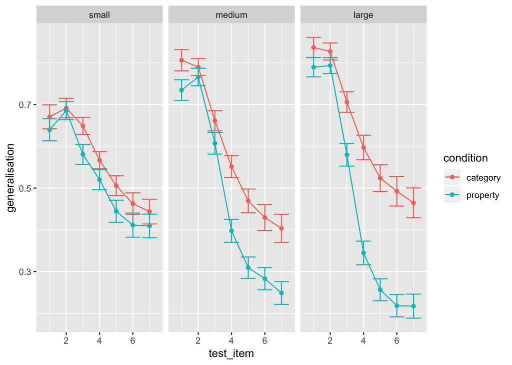

```r
fullframes <- frames %>%
  mutate(generalisation = (response+.1)/9.2) %>% mutate(id=factor(id)) %>%
  mutate(id=factor(id)) %>%
  mutate(sample_size = factor(sample_size, levels = c("small","medium","large")))

fullframes_avg <- fullframes %>%
  group_by(test_item, condition, sample_size) %>%
  summarise(
    n = n(),
    sd=sd(generalisation),
    se=sd/sqrt(n),
    generalisation = mean(generalisation),
    ) %>%
  ungroup()

expsummary <- fullframes_avg %>%
  ggplot(aes(x = test_item, y = generalisation, colour = condition)) +
  geom_line() +
  geom_point() +
  geom_errorbar(aes(ymin = generalisation - se, ymax = generalisation + se)) +
  facet_wrap(~sample_size)
plot(expsummary)
```

Eyeballing the data it seems clear that

1. responses are higher overall for the category than the property condition
2. responses decrease as test_item increases
3. there is an interaction between n_obs and test item (as n_obs increases, difference between small and large test items increases)
4. there is an interaction between test item and condition (as test_item increases, difference between category and property sampling increases)
5. there is an interaction between n_obs and condition (as n_obs increases, difference between category and property sampling increases)
6. there is a three-way interaction between n_obs, test item and condition condition (as n_obs increases, the interaction between test item and condition becomes more pronounced)

On the other hand, it’s not clear whether

7. the average response increases or decreases as n_obs increases

Frequentist and Bayesian methods can both be used to test these qualitative impressions.

## Frequentist approach

We first fit a full model with an intercept-only random effect.

```r
logitmod <- glmer(
  formula = generalisation ~ condition * test_item * n_obs + (1|id),
  family = gaussian(link = "logit"),
  data = fullframes)
```

There is a convergence issue, so we try a set of different optimization methods.

```r
af <- allFit(logitmod)
```

```
## bobyqa :
```

```
## [OK]
## Nelder_Mead :
```

```
## [OK]
## nlminbwrap :
```

[output not shown]

```
## [OK]
## nloptwrap.NLOPT_LN_BOBYQA :
```

[output not shown]

```
## [OK]
```

```r
summary(af)
```

```
## $which.OK
##                        bobyqa                   Nelder_Mead
##                          TRUE                          TRUE
##                    nlminbwrap                         nmkbw
##                          TRUE                         FALSE
##               optimx.L-BFGS-B nloptwrap.NLOPT_LN_NELDERMEAD
##                         FALSE                          TRUE
##     nloptwrap.NLOPT_LN_BOBYQA
##                          TRUE
##
## $msgs
## $msgs$bobyqa
## $msgs$bobyqa[[1]]
## [1] "Model failed to converge with max|grad| = 0.0017224 (tol = 0.001, component 1)"
##
## $msgs$bobyqa[[2]]
## [1] "Model is nearly unidentifiable: very large eigenvalue\n - Rescale variables?"
##
##
## $msgs$Nelder_Mead
## $msgs$Nelder_Mead[[1]]
## [1] "Model failed to converge with max|grad| = 0.0555489 (tol = 0.001, component 1)"
##
## $msgs$Nelder_Mead[[2]]
## [1] "Model is nearly unidentifiable: very large eigenvalue\n - Rescale variables?"
##
##
## $msgs$nlminbwrap
## $msgs$nlminbwrap[[1]]
## [1] "Model is nearly unidentifiable: very large eigenvalue\n - Rescale variables?"
##
##
## $msgs$nloptwrap.NLOPT_LN_NELDERMEAD
## $msgs$nloptwrap.NLOPT_LN_NELDERMEAD[[1]]
## [1] "Model failed to converge with max|grad| = 0.033128 (tol = 0.001, component 1)"
##
## $msgs$nloptwrap.NLOPT_LN_NELDERMEAD[[2]]
## [1] "Model is nearly unidentifiable: very large eigenvalue\n - Rescale variables?"
##
##
```

[output cut: 62 more lines]

```
## Nelder_Mead                      26.664    0.515  27.227          0         0
## nlminbwrap                        4.168    0.075   4.245          0         0
## nloptwrap.NLOPT_LN_NELDERMEAD     2.657    0.049   2.708          0         0
## nloptwrap.NLOPT_LN_BOBYQA         2.678    0.050   2.732          0         0
##
## $feval
##                        bobyqa                   Nelder_Mead
##                          6162                          4564
##                    nlminbwrap nloptwrap.NLOPT_LN_NELDERMEAD
##                            NA                           284
##     nloptwrap.NLOPT_LN_BOBYQA
##                           284
##
## attr(,"class")
## [1] "summary.allFit"
```

We get essentially the same estimates using several different optimization methods, so it looks like we’re OK despite the convergence warning. We’ll now compare the full model to a set of reduced models, each of which drops one of the terms in the formula.

```r
logitmod_no_condition <- glmer(
  formula = generalisation ~ test_item + n_obs + condition:test_item + condition:n_obs + test_item:n_obs + condition:test_item:n_obs + (1|id),
  family = gaussian(link = "logit"),
  data = fullframes)
```

```
## Warning in checkConv(attr(opt, "derivs"), opt$par, ctrl = control$checkConv, :
## Model failed to converge with max|grad| = 0.00152743 (tol = 0.001, component 1)
```

```
## Warning in checkConv(attr(opt, "derivs"), opt$par, ctrl = control$checkConv, : Model is nearly unidentifiable: very large eigenvalue
##  - Rescale variables?
```

```r
anova(logitmod, logitmod_no_condition)
```

```
## Data: fullframes
## Models:
## logitmod_no_condition: generalisation ~ test_item + n_obs + condition:test_item + condition:n_obs +
## logitmod_no_condition:     test_item:n_obs + condition:test_item:n_obs + (1 | id)
## logitmod: generalisation ~ condition * test_item * n_obs + (1 | id)
##                       Df     AIC    BIC logLik deviance  Chisq Chi Df
## logitmod_no_condition  9 -32.198 25.948 25.099  -50.198
## logitmod              10 -35.732 28.875 27.866  -55.732 5.5338      1
##                       Pr(>Chisq)
## logitmod_no_condition
## logitmod                 0.01865 *
## ---
## Signif. codes:  0 '***' 0.001 '**' 0.01 '*' 0.05 '.' 0.1 ' ' 1
```

```r
logitmod_no_test_item <- glmer(
  formula = generalisation ~ condition + n_obs + condition:test_item + condition:n_obs + test_item:n_obs + condition:test_item:n_obs + (1|id),
  family = gaussian(link = "logit"),
  data = fullframes)
anova(logitmod, logitmod_no_test_item)
```

```
## Data: fullframes
## Models:
## logitmod: generalisation ~ condition * test_item * n_obs + (1 | id)
## logitmod_no_test_item: generalisation ~ condition + n_obs + condition:test_item + condition:n_obs +
## logitmod_no_test_item:     test_item:n_obs + condition:test_item:n_obs + (1 | id)
##                       Df     AIC    BIC logLik deviance  Chisq Chi Df
## logitmod              10 -35.732 28.875 27.866  -55.732
## logitmod_no_test_item 10 -35.734 28.872 27.867  -55.734 0.0029      0
##                       Pr(>Chisq)
## logitmod
## logitmod_no_test_item  < 2.2e-16 ***
## ---
## Signif. codes:  0 '***' 0.001 '**' 0.01 '*' 0.05 '.' 0.1 ' ' 1
```

```r
logitmod_no_n_obs <- glmer(
  formula = generalisation ~ condition + test_item + condition:test_item + condition:n_obs + test_item:n_obs + condition:test_item:n_obs + (1|id),
  family = gaussian(link = "logit"),
  data = fullframes)
anova(logitmod, logitmod_no_n_obs)
```

```
## Data: fullframes
## Models:
## logitmod: generalisation ~ condition * test_item * n_obs + (1 | id)
## logitmod_no_n_obs: generalisation ~ condition + test_item + condition:test_item +
## logitmod_no_n_obs:     condition:n_obs + test_item:n_obs + condition:test_item:n_obs +
## logitmod_no_n_obs:     (1 | id)
##                   Df     AIC    BIC logLik deviance Chisq Chi Df Pr(>Chisq)
## logitmod          10 -35.732 28.875 27.866  -55.732
## logitmod_no_n_obs 10 -35.365 29.241 27.683  -55.365     0      0          1
```

```r
# TODO: add 4 more reduced models, one for each of the interaction terms
```

I’d like to say here that the results indicate that the main-effect terms for condition and test_item make an important contribution (p < 0.05 and p < 1e-15) but that the main-effect term for n_obs does not. But I don’t trust this at all – partly because of the convergence errors, partly because the AIC and BIC values don’t support this conclusion. Help?

If following this approach, the paper would include a writeup of the full model (including coefficients and standard errors) along with a writeup and interpretation of each model comparison.

## Bayesian approach (1)

We’ll now use the BayesFactor package to compare the set of reduced models to the full model. The package doesn’t support logistic regression so we’re using linear regressions here.

```r
full_bf <-  lmBF( generalisation ~ condition * test_item * n_obs + id, data=fullframes, whichRandom="id")
no_condition_bf <-  lmBF( generalisation ~ test_item + n_obs + condition:test_item + condition:n_obs + test_item:n_obs + condition:test_item:n_obs + id, data=fullframes, whichRandom="id")
summary(full_bf/no_condition_bf)
```

```
## Bayes factor analysis
## --------------
## [1] condition * test_item * n_obs + id : 19726.33 ±4.02%
##
## Against denominator:
##   generalisation ~ test_item + n_obs + condition:test_item + condition:n_obs + test_item:n_obs + condition:test_item:n_obs + id
## ---
## Bayes factor type: BFlinearModel, JZS
```

```r
no_test_item_bf <-  lmBF( generalisation ~ condition + n_obs + condition:test_item + condition:n_obs + test_item:n_obs + condition:test_item:n_obs + id, data=fullframes, whichRandom="id")
summary(full_bf/no_test_item_bf)
```

```
## Bayes factor analysis
## --------------
## [1] condition * test_item * n_obs + id : 1.56642e+331 ±2.79%
##
## Against denominator:
##   generalisation ~ condition + n_obs + condition:test_item + condition:n_obs + test_item:n_obs + condition:test_item:n_obs + id
## ---
## Bayes factor type: BFlinearModel, JZS
```

```r
no_n_obs_bf <-  lmBF( generalisation ~ condition + test_item + condition:test_item + condition:n_obs + test_item:n_obs + condition:test_item:n_obs + id, data=fullframes, whichRandom="id")
summary(full_bf/no_n_obs_bf)
```

```
## Bayes factor analysis
## --------------
## [1] condition * test_item * n_obs + id : 0.03700242 ±14.89%
##
## Against denominator:
##   generalisation ~ condition + test_item + condition:test_item + condition:n_obs + test_item:n_obs + condition:test_item:n_obs +     id
## ---
## Bayes factor type: BFlinearModel, JZS
```

```r
# TODO: add tests of interactions
```

Most of the Bayes factors are large, suggesting that the full model should be preferred to the reduced models. The one exception is the Bayes factor comparing the full model to the model without a main effect of n_obs. This Bayes factor is less than one, suggesting that the model without the main effect of n_obs should be preferred to the full model.

If following this approach, the paper would include a writeup and interpretation for each of the Bayes factors computed.

# Bayesian Approach (2)

Psychologists seem to expect hypothesis tests, so for a psychology paper I’d probably go for one of the previous two approaches. But some statisticians argue that the discrete hypothesis tests we’ve been using in previous sections are misguided — if we had enough data we’d be able to tell that *all* coefficients in the regression model are present (ie non-zero). From this perspective the real question is what we should believe about the magnitudes and sizes of these coefficients — and one way to answer this question is to report posterior distributions on these coefficients. We can achieve this using the brms package to fit a Bayesian regression model (here we use beta regression because the dependent variable is a probability).

```r
betamod_bayes <- brm(
  formula = generalisation ~ condition * test_item * n_obs + (1|id),
  family = Beta,
  data = fullframes)
summary(betamod_bayes)
```

```
##  Family: beta
##   Links: mu = logit; phi = identity
## Formula: generalisation ~ condition * test_item * n_obs + (1 | id)
##    Data: fullframes (Number of observations: 4725)
## Samples: 4 chains, each with iter = 2000; warmup = 1000; thin = 1;
##          total post-warmup samples = 4000
##
## Group-Level Effects:
## ~id (Number of levels: 225)
##               Estimate Est.Error l-95% CI u-95% CI Rhat Bulk_ESS Tail_ESS
## sd(Intercept)     0.65      0.04     0.58     0.72 1.01      874     1763
##
## Population-Level Effects:
##                                   Estimate Est.Error l-95% CI u-95% CI Rhat
## Intercept                             1.13      0.12     0.90     1.36 1.00
## conditionproperty                    -0.27      0.17    -0.60     0.06 1.00
## test_item                            -0.23      0.02    -0.27    -0.18 1.00
## n_obs                                 0.06      0.01     0.04     0.08 1.00
## conditionproperty:test_item           0.05      0.03    -0.01     0.11 1.00
## conditionproperty:n_obs               0.02      0.02    -0.01     0.06 1.00
## test_item:n_obs                      -0.01      0.00    -0.01    -0.00 1.00
## conditionproperty:test_item:n_obs    -0.02      0.00    -0.03    -0.01 1.00
##                                   Bulk_ESS Tail_ESS
## Intercept                             1234     2170
## conditionproperty                     1102     2007
## test_item                             1800     2414
## n_obs                                 1698     2641
## conditionproperty:test_item           1405     2426
## conditionproperty:n_obs               1565     2523
## test_item:n_obs                       1662     2374
## conditionproperty:test_item:n_obs     1468     2300
##
## Family Specific Parameters:
##     Estimate Est.Error l-95% CI u-95% CI Rhat Bulk_ESS Tail_ESS
## phi     2.26      0.04     2.18     2.35 1.00     4363     2771
##
## Samples were drawn using sampling(NUTS). For each parameter, Eff.Sample
## is a crude measure of effective sample size, and Rhat is the potential
## scale reduction factor on split chains (at convergence, Rhat = 1).
```

If following this approach, the paper would include a writeup of this single model along with plots showing posterior distributions on all coefficients.